# Loutre_analyse_GLMM

Pablo

2025-05-28

# 1 Problématique du stage

Je travaille sur un jeu de données d’un protocole de suivi de la loutre d’Europe sur 10 ans (environ 400 donnée), sur le bassin-versant côtier entre la baie de Lannion et Morlaix (**Secteur j25**).

Le protocole a pour but de s’appliquer à une échelle locale, d’un bassin-versant en considérant un secteur de 60 sites sélectionnés favorable au marquage (épreinte) de la loutre.

Un passage est effectué chaque année au printemps.

L’objectif de mon stage est de **déterminer si ce protocole permet de détecter des variations temporelles de l’intensité de marquage, à l’échelle des agrégats de 60 sites**. En cela, il serait un indicateur de l’évolution de l’état de la population, c’est le postulat de départ.

# 2 Importation des packages

# 3 Importation des données - Secteur J25 : Petit Tregor

```r
base_tregor <-
  readxl::read_xlsx(path = '../raw_data/export_suiviloutrelocal_telecharger_csv_2025_04_03_10h58m17.xlsx') %>%
  dplyr::select(
    id_dataset,
    code_secteur,
    code_site,
    nom_site,
    x_l93,
    y_l93,
    date_visite,
    observateurs,
    condition_prospection,
    nom_taxon,
    nom_complet_taxon,
    techn_observation,
    statut_observation,
    nb_ep_tot,
    nb_ep_w,
    nb_ep_dnf,
    nb_ep_df
  ) %>%
  mutate(
    annee = year(date_visite),
    mois = month(date_visite),
    jour = day(date_visite),
    nb_ep_w = abs(nb_ep_w),
    statut_observation = ifelse(str_detect(statut_observation, '^Pr'), yes = 'Présent', no = 'Absent')
  ) %>%
  filter(nom_complet_taxon =='Lutra lutra',
         !(id_dataset == 85 & code_secteur == "FR5300006"),
         code_secteur != "J401",
         !(annee == 2022)) %>%
  dplyr::distinct(code_site, annee, .keep_all = T)
```

=> Suppression de la valeur de 2022 qui est une erreur de saisie

# 4 Verifier les valeurs de la base de donnée

## 4.1 Jeu de données issus du Excel du prof de BTS avec correction

## 4.2 Jeu de données issus du Geonature du GMB

## 4.3 Comparaison des 2 jeu de données pour voir les différences entre les deux

On observe **32 erreurs** dans la base de données Geonature du GMB, sachant que les doublons ont été supprimé préalablement. On corrige donc le jeu de données base_j25 par les bonnes valeurs issus des valeurs du jeu de données bts.

## 4.4 Appliquer les correction du jeu de donnée BTS sur Base_J25

# 5 Représentation cartographique du secteur d’étude et des sites correspondants

[interactive chart not shown]

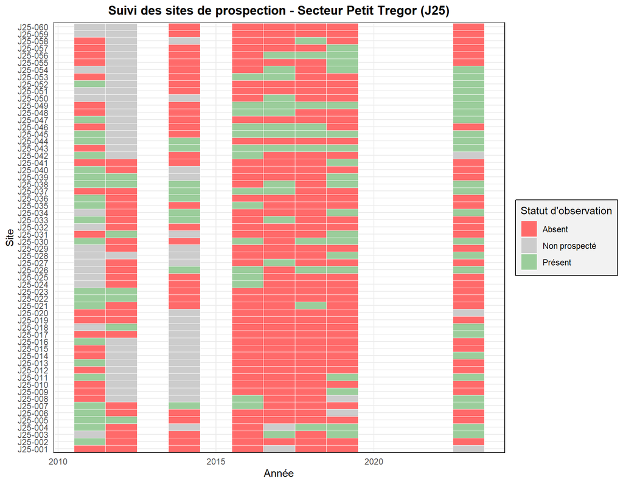

Figure 1: Statut d’observation des sites prospectée en fonction des années

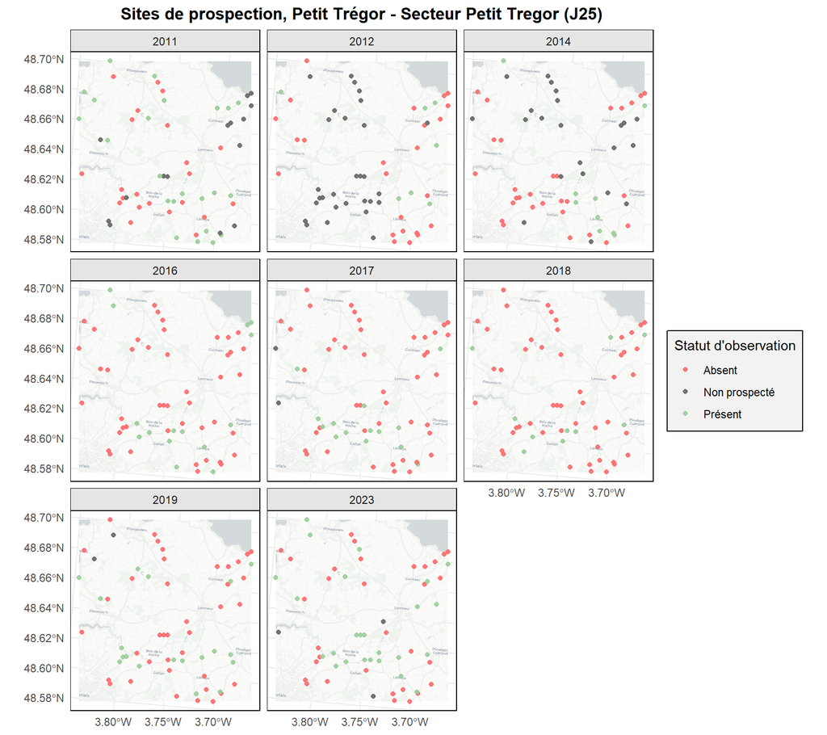

# Modèle 1 : Le statut d’observation depend de l’année (numeric)

## 5.1 Construction du modèle

### 5.1.1 **Definition des types de variables**

- **Variable réponse** : Statut_présence, variable qualitative binaire, nominale
- **Variable explicative** :
- Annee, variable quantitative
- Site, variable qualitative ordinale

### 5.1.2 **Choix de la distribution de référence**

=> **Distribution Binomiale**

### 5.1.3 **Choix de la fonction de lien**

=> **logit**

### 5.1.4 **Modèle mixte**

```r
base_j25_year_numeric <-  base_j25 %>%
  mutate(annee = as.numeric(annee),
         statut_presence = as.factor(statut_presence))
```

```r
mod3.0 <- glmer(statut_presence~annee+(1|code_site), family=binomial(link = "logit"), data = base_j25_year_numeric)
```

## 5.2 Vérification de l’ajustement du modèle aux données

- **Vérification de la linéarité du modèle**

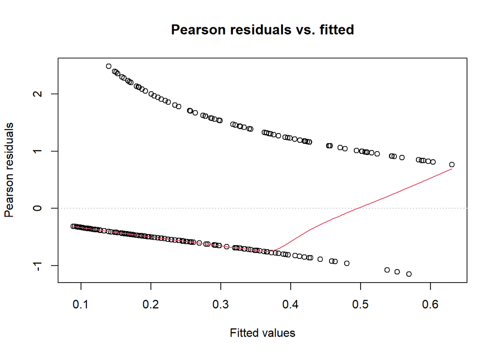

```r
plotresid(mod3.0)
```

La relation ne semble pas linéaire, il y a une structuration dans les résidus autrement dit dépendance entre les valeurs prédites (𝜇) et les résidus (𝜀).

### 5.2.1 **Remplacer la fonction de lien “logit” par “probit”**

```r
mod3.1 <- glmer(statut_presence~annee+(1|code_site), family=binomial(link = "probit"), data = base_j25_year_numeric)
```

**Vérification de l’indépendance des résidus**

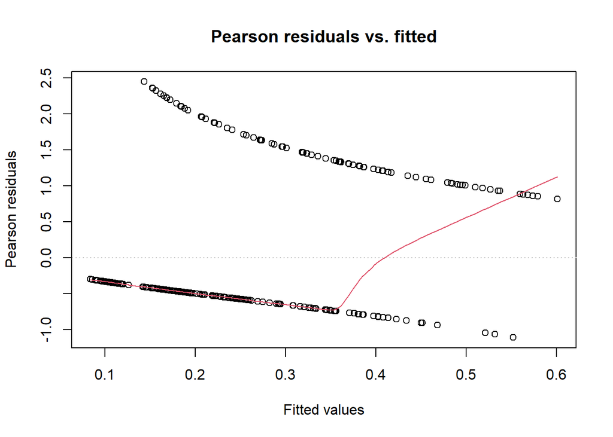

```r
plotresid(mod3.1)
```

La relation ne semble pas linéaire, il y a une structuration dans les résidus autrement dit dépendance entre les valeurs prédites (𝜇) et les résidus (𝜀).

### 5.2.2 **Remplacer la fonction de lien “logit” par “cauchit”**

```r
mod3.2 <- glmer(statut_presence~annee+(1|code_site), family=binomial(link = "cauchit"), data = base_j25_year_numeric)
```

**Vérification de l’indépendance des résidus**

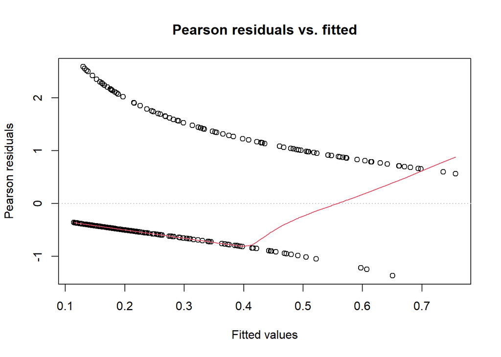

```r
plotresid(mod3.2)
```

## 5.3 Capacité explicative globale

** La fonction ne semble pas vouloir fonctionner lorsque la fonction de lien “cauchit” est utilisé

```r
r.squaredGLMM(mod3.0)
```

```
##                     R2m       R2c
## theoretical 0.002426768 0.2230218
## delta       0.001587524 0.1458947
```

```r
r.squaredGLMM(mod3.1)
```

```
##                     R2m       R2c
## theoretical 0.001864620 0.2375478
## delta       0.001074637 0.1369060
```

**Valeur des coefficients (estimate)**

```r
summary(mod3.2)
```

```
## Generalized linear mixed model fit by maximum likelihood (Laplace
##   Approximation) [glmerMod]
##  Family: binomial  ( cauchit )
## Formula: statut_presence ~ annee + (1 | code_site)
##    Data: base_j25_year_numeric
##
##      AIC      BIC   logLik deviance df.resid
##    434.5    446.6   -214.3    428.5      404
##
## Scaled residuals:
##     Min      1Q  Median      3Q     Max
## -1.3652 -0.5042 -0.4225 -0.3642  2.5896
##
## Random effects:
##  Groups    Name        Variance Std.Dev.
##  code_site (Intercept) 1.373    1.172
## Number of obs: 407, groups:  code_site, 60
##
## Fixed effects:
##               Estimate Std. Error z value Pr(>|z|)
## (Intercept) -1.642e+02  5.543e+00  -29.62   <2e-16 ***
## annee        8.067e-02  2.733e-03   29.52   <2e-16 ***
## ---
## Signif. codes:  0 '***' 0.001 '**' 0.01 '*' 0.05 '.' 0.1 ' ' 1
##
## Correlation of Fixed Effects:
##       (Intr)
## annee -0.999
## optimizer (Nelder_Mead) convergence code: 0 (OK)
## Model failed to converge with max|grad| = 0.362219 (tol = 0.002, component 1)
## Model is nearly unidentifiable: very large eigenvalue
##  - Rescale variables?
## Model is nearly unidentifiable: large eigenvalue ratio
##  - Rescale variables?
```

## 5.4 Exploitation du modèle

### 5.4.1 **Test de Wald**

```r
Anova(mod3.2)
```

```
## Analysis of Deviance Table (Type II Wald chisquare tests)
##
## Response: statut_presence
##        Chisq Df Pr(>Chisq)
## annee 871.31  1  < 2.2e-16 ***
## ---
## Signif. codes:  0 '***' 0.001 '**' 0.01 '*' 0.05 '.' 0.1 ' ' 1
```

## 5.5 Modèle 4 : Le statut d’observation depend de l’année (factor)

```r
base_j25_year_factor <- base_j25 %>%
  mutate(annee = as.factor(annee), code_site = as.factor(code_site), statut_presence = as.factor(statut_presence))
```

### 5.5.1 Construction du modèle

#### 5.5.1.1 **Definition des types de variables**

- **Variable réponse** : Statut_présence, variable qualitative binaire, nominale
- **Variable explicative** :
- Annee, variable qualitative ordinale
- Site, variable qualitative ordinale

#### 5.5.1.2 **Choix de la distribution de référence**

=> **Distribution Binomiale**

#### 5.5.1.3 **Choix de la fonction de lien**

=> **logit**

#### 5.5.1.4 **Modèle mixte**

```r
mod4.0<- glmer(statut_presence~annee+(1|code_site), family=binomial(link = "logit"), data = base_j25_year_factor)
```

### 5.5.2 Vérification de l’ajustement du modèle aux données

**Vérification de l’indépendance des résidus**

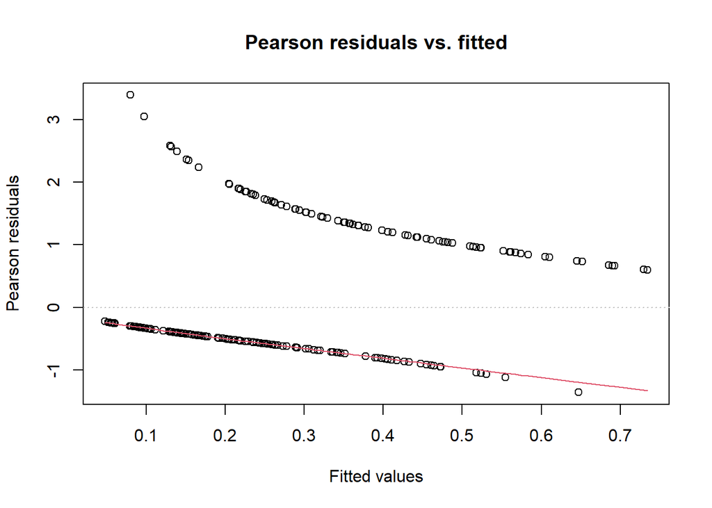

```r
plotresid(mod4.0)
```

#### 5.5.2.1 **Remplacer la fonction de lien “logit” par “cauchit”**

```r
mod4.1<- glmer(statut_presence~annee+(1|code_site), family=binomial(link = "cauchit"), data = base_j25_year_factor)
```

### 5.5.3 Vérification de l’ajustement du modèle aux données

**Vérification de l’indépendance des résidus**

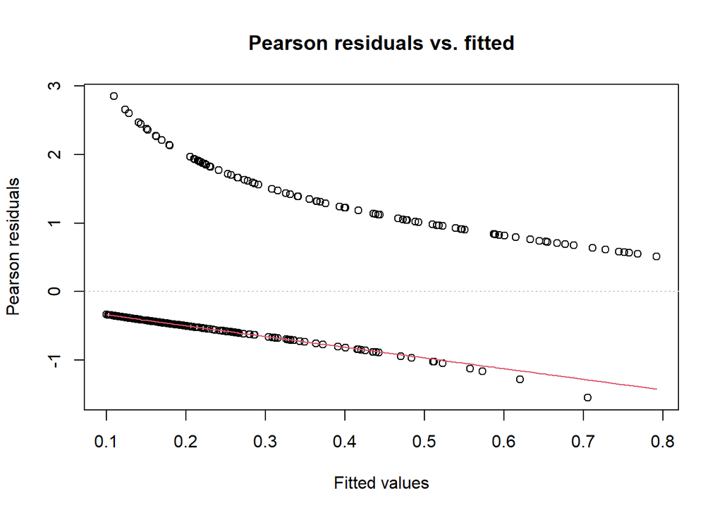

```r
plotresid(mod4.1)
```

**Valeur des coefficients (estimate)**

```r
summary(mod4.1)
```

```
## Generalized linear mixed model fit by maximum likelihood (Laplace
##   Approximation) [glmerMod]
##  Family: binomial  ( cauchit )
## Formula: statut_presence ~ annee + (1 | code_site)
##    Data: base_j25_year_factor
##
##      AIC      BIC   logLik deviance df.resid
##    438.0    474.1   -210.0    420.0      398
##
## Scaled residuals:
##     Min      1Q  Median      3Q     Max
## -1.5481 -0.5092 -0.4196 -0.3394  2.8501
##
## Random effects:
##  Groups    Name        Variance Std.Dev.
##  code_site (Intercept) 1.352    1.163
## Number of obs: 407, groups:  code_site, 60
##
## Fixed effects:
##             Estimate Std. Error z value Pr(>|z|)
## (Intercept) -1.03506    0.49687  -2.083   0.0372 *
## annee2012   -0.95209    0.80084  -1.189   0.2345
## annee2014   -1.32295    0.88174  -1.500   0.1335
## annee2016   -0.47156    0.61243  -0.770   0.4413
## annee2017   -0.72231    0.62621  -1.153   0.2487
## annee2018   -1.07467    0.68490  -1.569   0.1166
## annee2019   -0.08432    0.56412  -0.149   0.8812
## annee2023    0.25506    0.53092   0.480   0.6309
## ---
## Signif. codes:  0 '***' 0.001 '**' 0.01 '*' 0.05 '.' 0.1 ' ' 1
##
## Correlation of Fixed Effects:
##           (Intr) an2012 an2014 an2016 an2017 an2018 an2019
## annee2012 -0.391
## annee2014 -0.439  0.248
## annee2016 -0.685  0.371  0.425
## annee2017 -0.602  0.402  0.378  0.548
## annee2018 -0.558  0.339  0.326  0.487  0.476
## annee2019 -0.715  0.411  0.424  0.595  0.573  0.507
## annee2023 -0.798  0.410  0.416  0.647  0.579  0.525  0.665
```

## 5.6 Modele 6 : Retirer les Années avec des troues de prospections temporelles

```r
base_j25_year_factor_filter <- base_j25 %>%
  filter(code_secteur == "J25",
         annee == c(2017, 2018, 2019, 2020, 2021, 2023)) %>%
  mutate(
    annee = as.factor(annee),
    code_site = as.factor(code_site),
    statut_presence = as.factor(statut_presence)
  )
```

### 5.6.1 Construction du modèle

#### 5.6.1.1 **Definition des types de variables**

- **Variable réponse** : Statut_présence, variable qualitative binaire, nominale
- **Variable explicative** :
- Annee, variable qualitative ordinale
- Site, variable qualitative ordinale

#### 5.6.1.2 **Choix de la distribution de référence**

=> **Distribution Binomiale**

#### 5.6.1.3 **Choix de la fonction de lien**

=> **logit**

#### 5.6.1.4 **Modèle mixte**

```r
mod6.0<- glmer(statut_presence~annee+(1|code_site), family=binomial(link = "logit"), data = base_j25_year_factor_filter)
```

### 5.6.2 Vérification de l’ajustement du modèle aux données

**Vérification de l’indépendance des résidus**

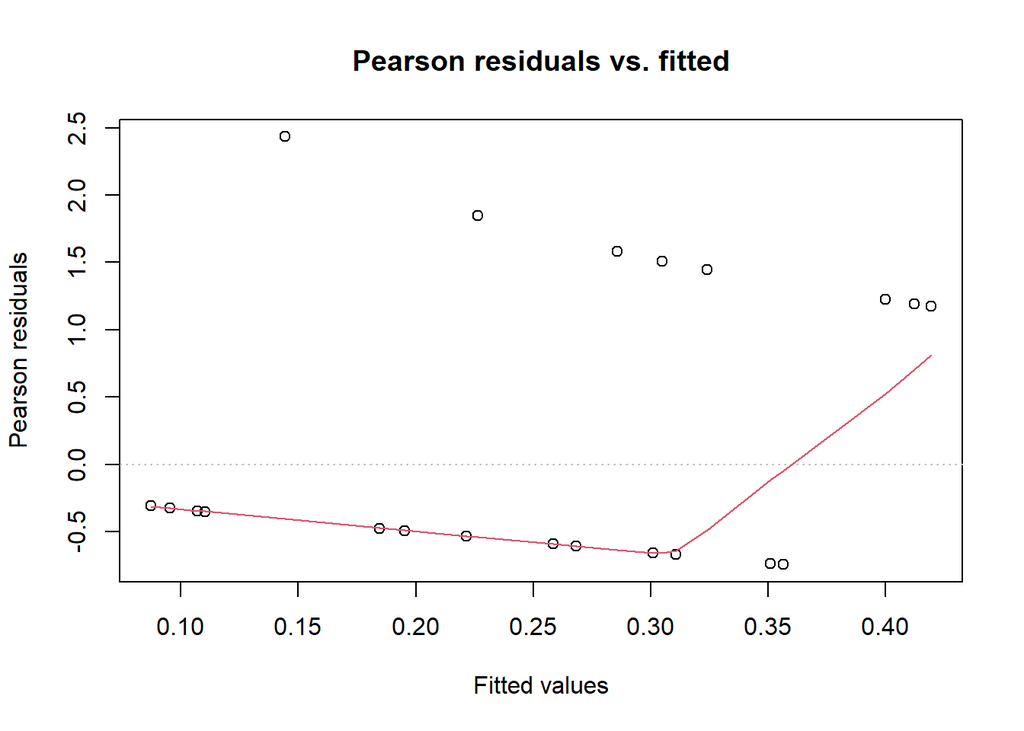

```r
plotresid(mod6.0)
```

#### 5.6.2.1 **Remplacer la fonction de lien “logit” par “probit”**

```r
mod6.1<- glmer(statut_presence~annee+(1|code_site), family=binomial(link = "probit"), data = base_j25_year_factor_filter)
```

### 5.6.3 Vérification de l’ajustement du modèle aux données

**Vérification de l’indépendance des résidus**

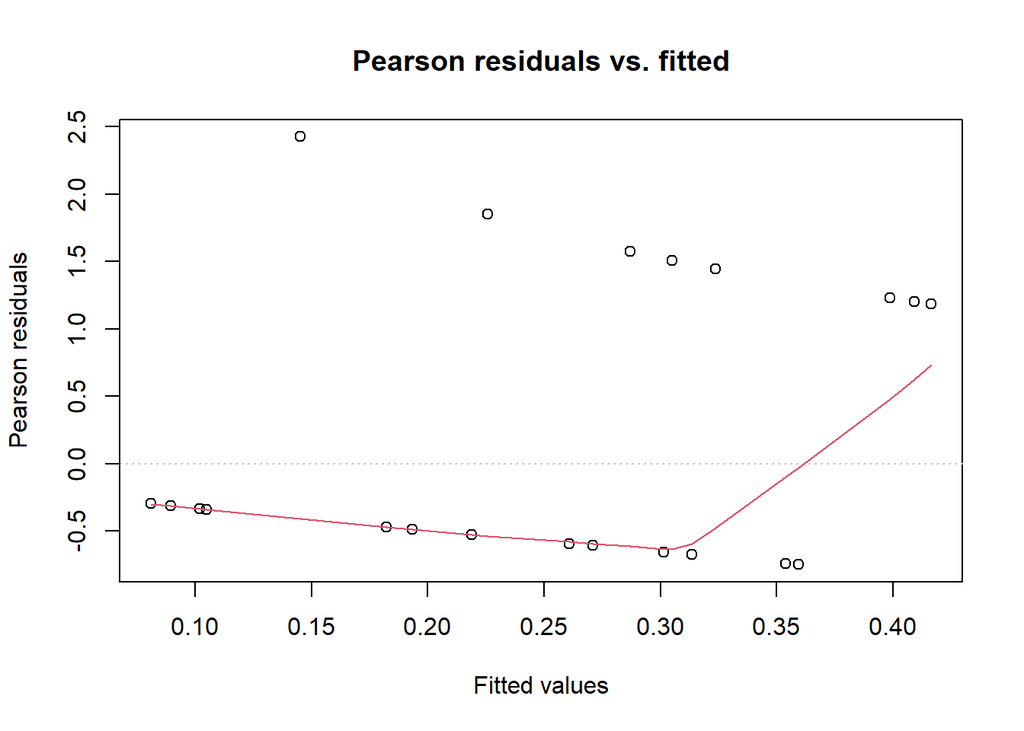

```r
plotresid(mod6.1)
```

**Valeur des coefficients (estimate)**

```r
summary(mod6.1)
```

```
## Generalized linear mixed model fit by maximum likelihood (Laplace
##   Approximation) [glmerMod]
##  Family: binomial  ( probit )
## Formula: statut_presence ~ annee + (1 | code_site)
##    Data: base_j25_year_factor_filter
##
##      AIC      BIC   logLik deviance df.resid
##     55.3     63.9    -22.6     45.3       36
##
## Scaled residuals:
##     Min      1Q  Median      3Q     Max
## -0.7492 -0.6095 -0.4897  1.1838  2.4260
##
## Random effects:
##  Groups    Name        Variance Std.Dev.
##  code_site (Intercept) 0.09785  0.3128
## Number of obs: 41, groups:  code_site, 32
##
## Fixed effects:
##             Estimate Std. Error z value Pr(>|z|)
## (Intercept)  -0.5658     0.4736  -1.195    0.232
## annee2018    -0.7612     0.7786  -0.978    0.328
## annee2019     0.2631     0.5915   0.445    0.657
## annee2023    -0.2663     0.6632  -0.402    0.688
##
## Correlation of Fixed Effects:
##           (Intr) an2018 an2019
## annee2018 -0.394
## annee2019 -0.772  0.341
## annee2023 -0.547  0.426  0.446
```

#### 5.6.3.1 **Remplacer la fonction de lien “logit” par “cloglog”**

```r
mod6.2<- glmer(statut_presence~annee+(1|code_site), family=binomial(link = "cloglog"), data = base_j25_year_factor_filter)
```

### 5.6.4 Vérification de l’ajustement du modèle aux données

**Vérification de l’indépendance des résidus**

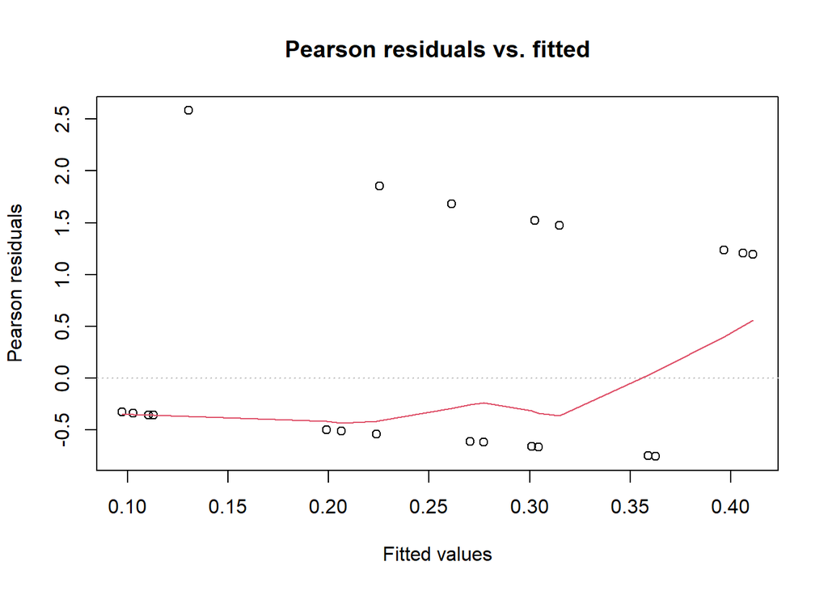

```r
plotresid(mod6.2)
```

## 5.7 Modele 7 : Le station d’observation dépend de l’année, des conditions de prospection

```r
base_j25_year_factor <- base_j25 %>%
  filter(code_secteur == "J25",
         annee == c(2017, 2018, 2019, 2020, 2021, 2023)) %>%
  mutate(
    annee = as.factor(annee),
    code_site = as.factor(code_site),
    statut_presence = as.factor(statut_presence),
    condition_prospection = as.factor(condition_prospection)
  )
```

### 5.7.1 Construction du modèle

#### 5.7.1.1 **Definition des types de variables**

=> **Distribution Binomiale**

#### 5.7.1.2 **Choix de la fonction de lien**

=> **logit**

#### 5.7.1.3 **Modèle mixte**

```r
mod7.0<- glmer(statut_presence~annee+condition_prospection+(1|code_site), family=binomial(link = "logit"), data = base_j25_year_factor)
```

### 5.7.2 Vérification de l’ajustement du modèle aux données

**Vérification de l’indépendance des résidus**

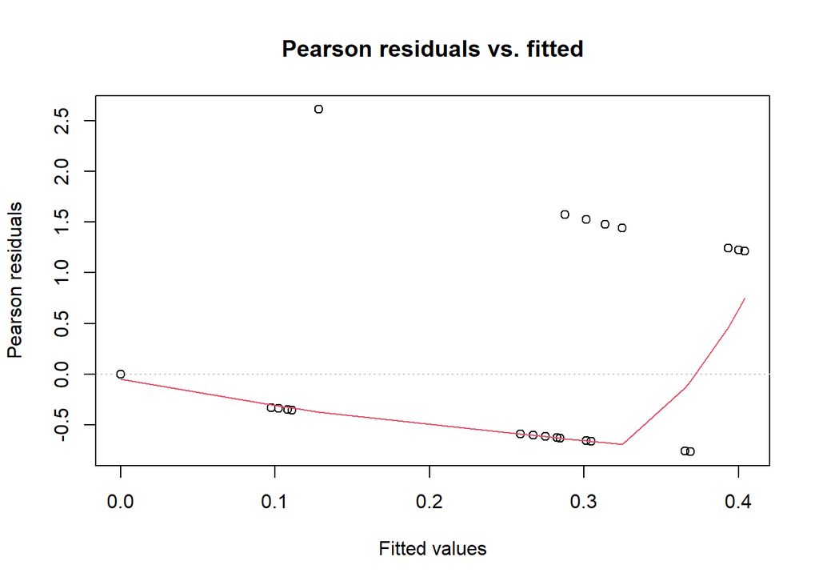

```r
plotresid(mod7.0)
```

#### 5.7.2.1 **Remplacer la fonction de lien “logit” par “probit”**

```r
mod7.1<- glmer(statut_presence~annee+condition_prospection+(1|code_site), family=binomial(link = "probit"), data = base_j25_year_factor)
```

**Vérification de l’indépendance des résidus**

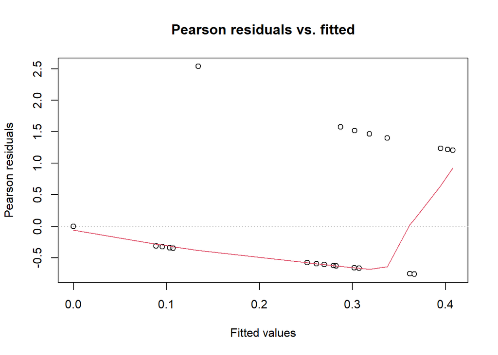

```r
plotresid(mod7.1)
```

#### 5.7.2.2 **Remplacer la fonction de lien “logit” par “cloglog”**

```r
mod7.2 <- glmer(statut_presence~annee+condition_prospection+(1|code_site), family=binomial(link = "cloglog"), data = base_j25_year_factor)
```

**Vérification de l’indépendance des résidus**

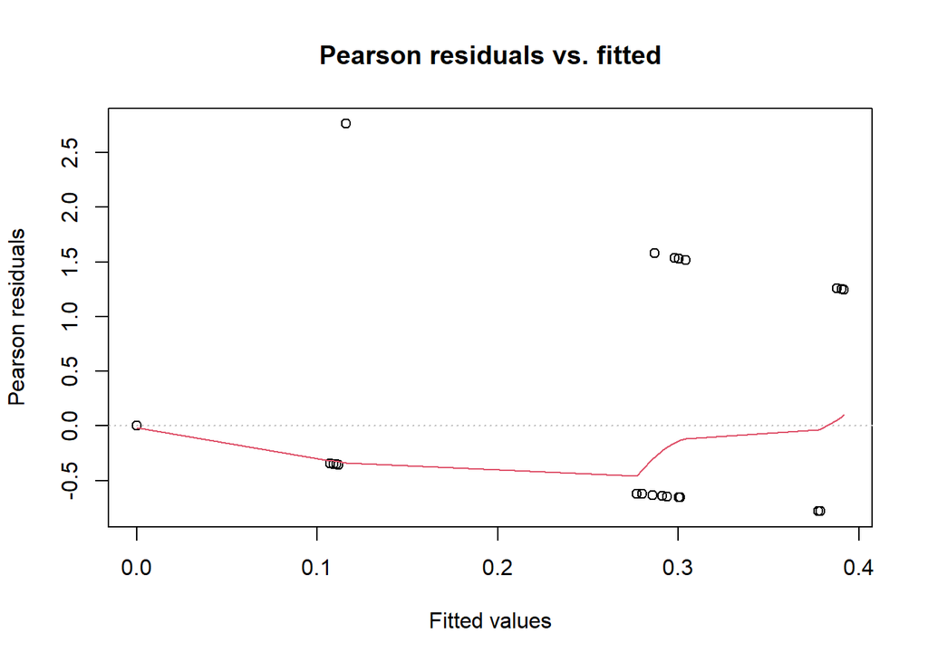

```r
plotresid(mod7.2)
```

# 6 sauvegarde des données prétraitées

```r
save(base_j25_year_numeric,
     file = "../processed_data/base_j25_year_numeric.rda")
```